# Общая канва

## 1. Характеристика материала

В качестве матрицы зависимых переменных будем использовать количество пойманных птиц деленное на количество дней отловов. То есть количество птиц данного вида, приходящееся на один день отлова.

Карта расположения точек отлова птиц.Размер точки пропорционален количеству дней отлова.

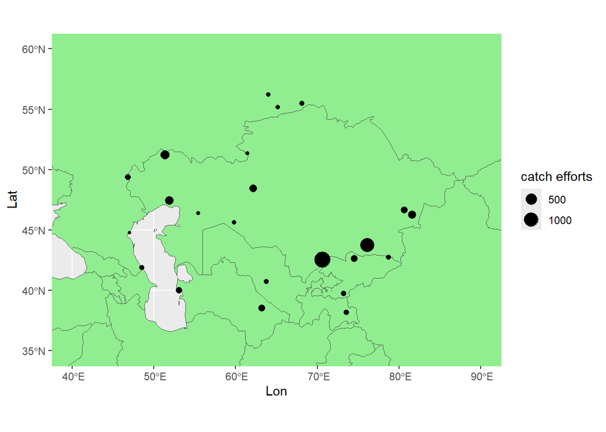

## Модель географической приуроченности видов

Главными предикторами, в соответствии с задачей, будем рассматривать географические координаты (Lon, Lat). Однако соотношение численностей видов птиц может контролироваться еще и тем, в какой стации были установлены сети.

Для обхода этой проблемы в качестве ковариат будут использоваться обилие трех групп птиц, различающихся по своей “экологии”.

- **Phyl** - “пеночки”
- **Acro** - “камышевки”
- **Fice** - “мухоловки”

NB!Нужно в явном виде сформулировать суть различия “экологии” групп. Вопрос. Нет ли возможности отразить какой-то средовой признак, коррелирующий с экологией групп на карте? Например покрытие лесами, травянистость, околоводность etc.

Зависимая переменная: вероятность встречи *вида* среди отловленных птиц, оцененная по доле каждого вида в общей численности пойманных на данной станции птиц.

Эта переменная представлена матрицей (колонки виды, строки станции отлова).

Для построения модели используем CCA.

Полученные в анализе канонические оси в сумме описывают 62.3% общей инерции (of total Inertia). Сама модель была статистически значимой (здесь и далее для оценки величины p-value использована пермутационная процедура при 9999 пермутациях).

| term | df | ChiSquare | statistic | p.value |
| --- | --- | --- | --- | --- |
| Model | 5 | 1.788398 | 6.266546 | 1e-04 |
| Residual | 19 | 1.084475 | NA | NA |

При этом статистически значимыми были все пять канонических осей.

| term | df | ChiSquare | statistic | p.value |
| --- | --- | --- | --- | --- |
| CCA1 | 1 | 0.5913466 | 10.360393 | 0.0001 |
| CCA2 | 1 | 0.5093535 | 8.923873 | 0.0001 |
| CCA3 | 1 | 0.3401525 | 5.959471 | 0.0001 |
| CCA4 | 1 | 0.1876171 | 3.287052 | 0.0225 |
| CCA5 | 1 | 0.1599281 | 2.801940 | 0.0247 |
| Residual | 19 | 1.0844749 | NA | NA |

Для трактовки канонических осей рассмотрим связь этих осей с ковариатами.

|  | CCA1 | CCA2 | CCA3 |
| --- | --- | --- | --- |
| Acro_per_Day | -0.8857885 | 0.1062850 | 0.2850023 |
| Fice_per_Day | 0.1126784 | -0.6401423 | -0.6372775 |
| Phyl_per_Day | 0.4663676 | -0.5085631 | 0.4930048 |
| Lat | 0.3291029 | -0.6261298 | 0.5367975 |
| Lon | 0.4594741 | 0.7048074 | 0.3797659 |

- CCA1 (20.6% общей инерции) - Самая высокая нагрузка у Acro_per_Day
- CCA2 (17.7% общей инерции) - Самая высокая нагрузка у Lon
- CCA3 (11.8% общей инерции) - Самая высокая нагрузка у Fice_per_Day

Далее мы работаем с CCA2, которая отражает и географические компоненты, которые находятся в фокусе исследования, и влияние “экологии” групп птиц.

## Связь географии отлова с географией зимовки

Географию зимовки оцениваем по центроиду ареала зимовки. Наша гипотеза - между ареалом (центроидом) зимовки и CCA2 должна быть корреляция.

Для двух видов западные и восточные виды были рассмотрены как один комплекс, который потенциаоно не различали кольцеватели.

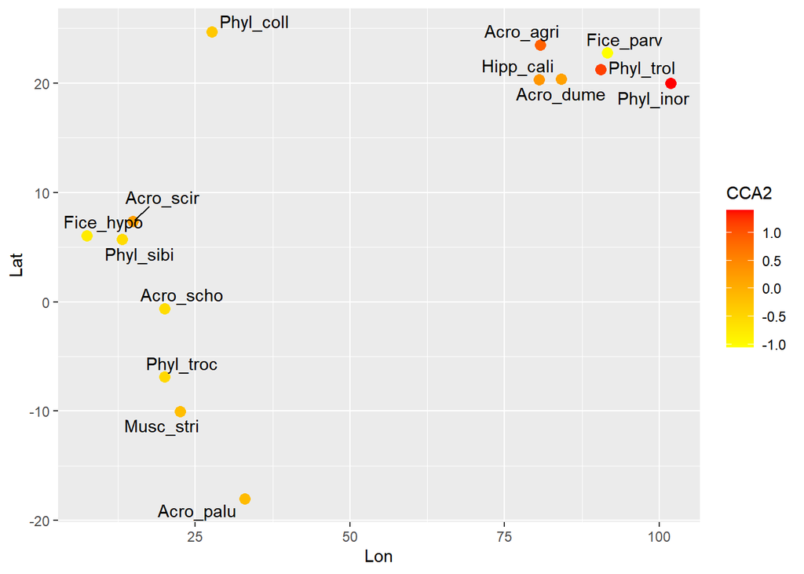

Видно, что вырисовываются два облака. Левое это африканские зимовщики, правое - Индо-Азиатские зимовщики. Те виды, что зимуют в Африке, в основном, имеют отрицательные нагрузки по ССА2 Большинство видов, что зимуют в Индии и Азии имеют положительные нагрузки по ССА2.

Для проверки связи между CCA2 (характеризует географию отловов) и долготой центроида ареала зимовки строим робустную регрессию, которая описывает тенденцию, лишенную влияния аутлаеров.

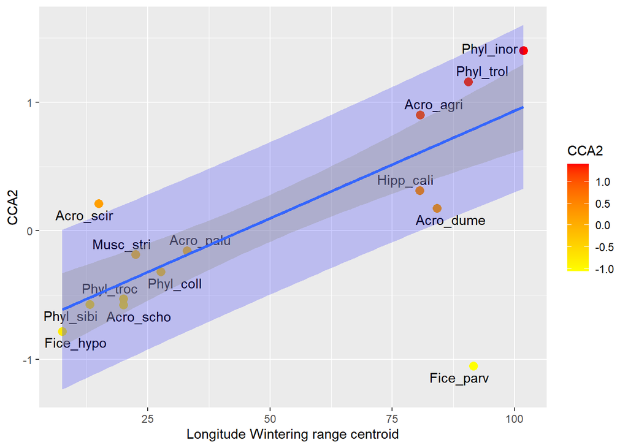

Построенная модель позволяет сделать два заключения

1. Существует связь между географией отлова с географией зимовки. Иными словами те птицы, которые с большей вероятностью ловятся на западе, летят на запад. И наоборот.
2. Есть некоторое количество аутлаевров, которые не вписываются в предсказания этой модели. Для выявления таких видов можно построить область предсказаний модели или отфильровать виды по величине остатков модели (взять тех, кто за пределами 0.025 и 0.975 квантилей)

Оба метода дают два однозначных аутлаера:

- Fice_prav (+Fice_albi) много ловится на западе, хотя ей лететь на восток.
- Acro_scir ловится часто на востоке, но лететь ей на запад, в Африку.

Можно расширить границы поиска аутлаеров.

## Приложение: карты ареалов видов

Пока в работе